# Pitcher Rankings Baseball

[figure not shown]

## Top 15 Pitchers by Velocity

velo_Max = Highest FB velocity recorded by each pitcher  
velo_AVGFB = Average of all FB veloicty recorded by each pitcher

|  | Name | Handed | Rank | velo_MAX | velo_AVGFB |
| --- | --- | --- | --- | --- | --- |
| 1 | Jack Bradfield | R | 1 | 99.309 | 95.7908432432432 |
| 2 | Mel Clark | R | 2 | 98.841 | 94.8039566326531 |
| 3 | Hank Murphy | R | 3 | 97.818 | 93.6851978798587 |
| 4 | Ben Williams | L | 4 | 97.777 | 93.7375406125166 |
| 5 | Lonnie Ritter | R | 5 | 96.723 | 92.9832136894825 |
| 6 | George Knox | L | 6 | 96.623 | 93.8944102564103 |
| 7 | Mickey Scales | R | 7 | 96.506 | 92.8450431432974 |
| 8 | Jim Bowers | L | 8 | 96.461 | 93.9532110091743 |
| 9 | Roger Bomman | R | 9 | 96.423 | 92.6176648351648 |
| 10 | Ed Dweeb | R | 10 | 96.059 | 93.3001025641026 |

[output cut: 5 more lines]

## Top 15 Pitchers by Spin Rate

- This ranking is composed of:
  - Average Faseball Spin Rate 30%
  - Average change Up Spin Rate 30%
  - Average Breaking Ball Spin Rate 40%

Spin_AVGFB = Average of all FB spin rate recorded by each pitcher  
Spin_AVGBRK = Average of all BRK spin rate recorded by each pitcher  
Spin_AVGCH = Average of all CH spin rate recorded by each pitcher

|  | Name | Handed | Rank | Spin_AVGFB | Spin_AVGBRK | Spin_AVGCH |
| --- | --- | --- | --- | --- | --- | --- |
| 1 | Davis Birch | R | 1 | 2675.37150274725 | 3015.19096428571 | 2504.1331875 |
| 2 | Ken Strout | R | 2 | 2459.37196189024 | 2672.07878896104 | 1952.63725 |
| 3 | Mickey Scales | R | 3 | 2315.02005392912 | 2523.41273291925 | 1914.72135294118 |
| 4 | George Knox | L | 4 | 2567.77642735043 | 2435.79764285714 | 2084.06254761905 |
| 5 | Hank Murphy | R | 5 | 2478.01061837456 | 2691.86671638142 | 1955.36630136986 |
| 6 | Lou Collins | L | 6 | 2127.52752185792 | 2727.135390625 | 2296.10612650602 |
| 7 | Billy Chapel | L | 7 | 2225.78965306122 | 2619.15802446483 | 1965.70784745763 |
| 8 | Mickey Hart | R | 8 | 2158.71019230769 | 2374.1748 | 1807.30628571429 |
| 9 | Mel Clark | R | 9 | 2537.47543622449 | 2219.45059825328 | 1603.0306779661 |
| 10 | Billy Heywood | L | 11 | 2183.54679591837 | 2341.73093939394 | 1117.22513513514 |

[output cut: 5 more lines]

## Top 15 Pitchers by Extension

- This ranking is composed of:
  - Average Faseball Extension 35%
  - Average change Up Extension 32.5%
  - Average Breaking Ball Extension 32.5%

ext_AVGFB = Average of all FB extension recorded by each pitcher  
ext_AVGBRK = Average of all BRK extension recorded by each pitcher  
ext_AVGCH = Average of all CH extension recorded by each pitcher

|  | Name | Handed | Rank | ext_AVGFB | ext_AVGCH | ext_AVGBRK |
| --- | --- | --- | --- | --- | --- | --- |
| 1 | Jake Taylor | R | 1 | 7.07340976744186 | 6.89123965517241 | 6.68255384615385 |
| 2 | George Knox | L | 2 | 6.86013504273504 | 6.75002857142857 | 6.38263 |
| 3 | Terrence Mann | R | 3 | 6.84996037151703 | 6.72308181818182 | 5.93776006191951 |
| 4 | Mickey Hart | R | 4 | 6.61875576923077 | 6.42451428571429 | 6.16636 |
| 5 | Pete Klein | R | 5 | 6.38503648648649 | 6.9055375 | 5.81846315789474 |
| 6 | Mickey Scales | R | 6 | 6.32201402157165 | 6.90184117647059 | 5.98539751552795 |
| 7 | Larry Fisher | R | 7 | 6.67434952606635 | 6.33345797101449 | 6.03626302083333 |
| 8 | Hank Murphy | R | 8 | 6.65107526501767 | 6.22028493150685 | 6.13358361858191 |
| 9 | Rudy Bonilla | R | 9 | 6.37843292682927 | 6.66392068965517 | 5.95634141414141 |
| 10 | Jim Bowers | L | 10 | 7.08461972477064 |  | 6.74201071428571 |

[output cut: 5 more lines]

## Top 15 Pitchers Overall

This ranking is composed of the Rankings above and the display chart below.

Ulimate Pitcher Rating = This is the combine score of the graph below for each pitcher

|  | Name | Handed | Rank | Ultimate Pitcher Rating |
| --- | --- | --- | --- | --- |
| 1 | Mel Clark | R | 1 | 21.99 |
| 2 | Mickey Scales | R | 2 | 21.705 |
| 3 | Hank Murphy | R | 3 | 20.05625 |
| 4 | Pete Klein | R | 4 | 20.005 |
| 5 | George Knox | L | 5 | 19.9025 |
| 6 | Jim Bowers | L | 6 | 19.8975 |
| 7 | Ben Williams | L | 7 | 19.5275 |
| 8 | Roger Bomman | R | 8 | 18.4175 |
| 9 | Ken Strout | R | 9 | 18.1625 |
| 10 | Jack Bradfield | R | 10 | 17.71 |

[output cut: 5 more lines]

## Top Pitcher Breakdown

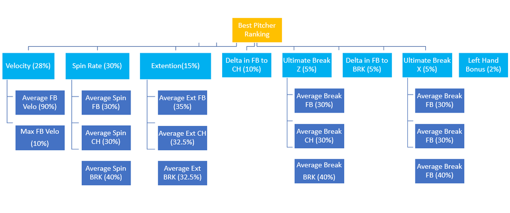